# Human Activity Recognition

Rafael Mendes

20/09/2014

First, we need to load the dataset:

```r
setwd('/home/fatchel/coursera/practical machine learning')
data = read.csv('pml-training.csv')
```

Doing some exploratory analysis, we identify that we have a lot of features missing values. So, we write a little function to inspect all these features and calculate a percentage of missing information. For our surprise, our dataset is fragmented basically in two uniform distributions: feeatures that have 100% of information, and features that have about 2% of information.

```r
infoColunasTrain <- matrix(ncol=2, nrow=ncol(data))
j = 1
for (i in colnames(data)) {
  infoColunasTrain[j,1] = i
  infoColunasTrain[j,2] = as.numeric(as.numeric(sum(!is.na(data[,i]) & data[,i] != '') / nrow(data))*100)
  j = j + 1
}
df = data.frame(infoColunasTrain)
colnames(df)= c('ColumnName','InformationPercentage')
df$InformationPercentage = as.numeric(as.character(df$InformationPercentage))
```

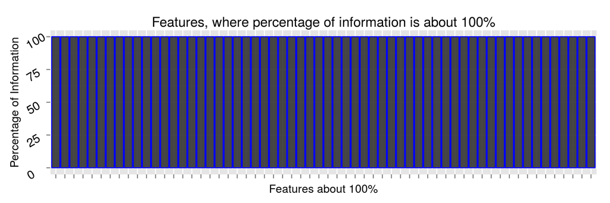

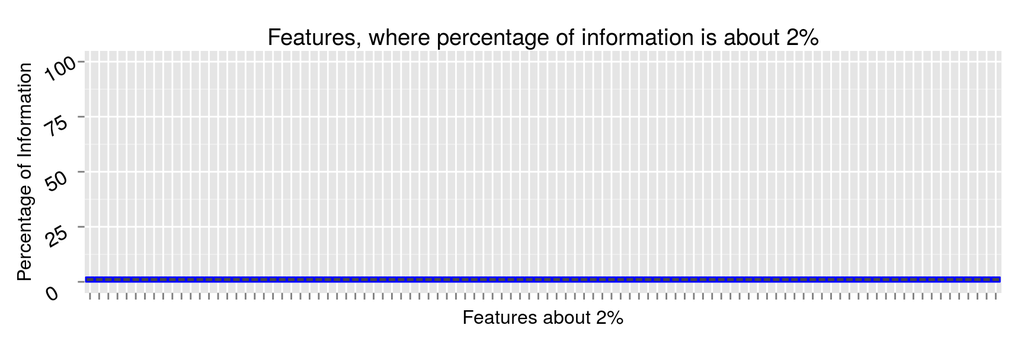

So, we just throw out all features that have about 2% of information and create our training/hold out datasets, but, before, we need discard some features that’s no make sense in our analysis, or do not explain reasonable variance:

```r
data_completed = data[,colnames(data)[df$InformationPercentage / 100 == 1.0]]
data_completed$X = NULL
data_completed$user_name = NULL
data_completed$cvtd_timestamp = NULL
data_completed$new_window = NULL

set.seed(32323)
split = createDataPartition(data_completed$classe, p=0.60, list=FALSE)
train = data_completed[split,]
test = data_completed[-split,]
```

Now we will use our datasets to fit a random forest model based, and accordingly with this link: http://www.stat.berkeley.edu/~breiman/RandomForests/cc_home.htm#ooberr, we don’t need to make cross validation.

```r
registerDoParallel()
m = train(classe ~  . -num_window, data=train, method='rf')
p = predict(m$finalModel, newdata=test, type='class')
```

So, this is our confusion matrix:

```r
confusionMatrix(p,test$classe)
```

```
## Confusion Matrix and Statistics
##
##           Reference
## Prediction    A    B    C    D    E
##          A 2231    4    0    0    0
##          B    1 1514    3    0    0
##          C    0    0 1363    1    1
##          D    0    0    2 1285    3
##          E    0    0    0    0 1438
##
## Overall Statistics
##
##                Accuracy : 0.998
##                  95% CI : (0.997, 0.999)
##     No Information Rate : 0.284
##     P-Value [Acc > NIR] : <2e-16
##
##                   Kappa : 0.998
##  Mcnemar's Test P-Value : NA
##
## Statistics by Class:
##
##                      Class: A Class: B Class: C Class: D Class: E
## Sensitivity             1.000    0.997    0.996    0.999    0.997
## Specificity             0.999    0.999    1.000    0.999    1.000
## Pos Pred Value          0.998    0.997    0.999    0.996    1.000
## Neg Pred Value          1.000    0.999    0.999    1.000    0.999
## Prevalence              0.284    0.193    0.174    0.164    0.184
## Detection Rate          0.284    0.193    0.174    0.164    0.183
## Detection Prevalence    0.285    0.193    0.174    0.164    0.183
## Balanced Accuracy       0.999    0.998    0.998    0.999    0.999
```

And our model:

```r
m$finalModel
```

```
##
## Call:
##  randomForest(x = x, y = y, mtry = param$mtry)
##                Type of random forest: classification
##                      Number of trees: 500
## No. of variables tried at each split: 28
##
##         OOB estimate of  error rate: 0.25%
## Confusion matrix:
##      A    B    C    D    E class.error
## A 3346    2    0    0    0   0.0005974
## B    4 2272    3    0    0   0.0030715
## C    0    4 2044    6    0   0.0048685
## D    0    0    7 1922    1   0.0041451
## E    0    0    1    2 2162   0.0013857
```